```python
import numpy as np
import pandas as pd
```

# Class4: 3rd January, 2021, Sunday

# The Pandas DataFrame Object

A DataFrame represents a rectangular table of data and contains an ordered collec‐ tion of columns, each of which can be a different value type (numeric, string, boolean, etc.).

```
Series object single dimension ki hoti hai, jabke dataframe object rectangular dimension ka hota hai
```

### Creating a DataFrame from scratch

```python
# Create a DataFrame from a 2d ndarray

# df = pd.DataFrame(np.array([[10, 11, 12, 13, 12], [20, 21, 22, 23]]))  error dega>> no of cols !=

df = pd.DataFrame(np.array([[10, 11, 12, 13], [20, 21, 22, 23]]))
df

# default row and column indexes

# number of columns dono mai equal hone chahiyen warna ye error dega
# series mai sirf row index hota hai jabke dataframe main row and col index dono hain
```

|  | 0 | 1 | 2 | 3 |
| --- | --- | --- | --- | --- |
| 0 | 10 | 11 | 12 | 13 |
| 1 | 20 | 21 | 22 | 23 |

```python
# Create a DataFrame from a list of series objects

df1 = pd.DataFrame([pd.Series(np.arange(10,15)),
                   pd.Series(np.arange(15,20))])

df1

# default row and col indexes
```

|  | 0 | 1 | 2 | 3 | 4 |
| --- | --- | --- | --- | --- | --- |
| 0 | 10 | 11 | 12 | 13 | 14 |
| 1 | 15 | 16 | 17 | 18 | 19 |

```python
# Create a DataFrame from two Series objects
# and a dictionary

s1 = pd.Series(np.arange(1, 6, 1))

s2 = pd.Series(np.arange(6, 11, 1))

df2 = pd.DataFrame({'boys': s1, 'girls': s2})
df2

# keys hamari automatically col indices banjati hain
```

|  | boys | girls |
| --- | --- | --- |
| 0 | 1 | 6 |
| 1 | 2 | 7 |
| 2 | 3 | 8 |
| 3 | 4 | 9 |
| 4 | 5 | 10 |

```python
data = {'name': ["Shahid", "Sadiq", "Kashif", "Rashid"], 'age': [20,26,36,40], 'grades': ["A","B","A","B"]}

data = pd.DataFrame(data)

data
```

|  | name | age | grades |
| --- | --- | --- | --- |
| 0 | Shahid | 20 | A |
| 1 | Sadiq | 26 | B |
| 2 | Kashif | 36 | A |
| 3 | Rashid | 40 | B |

```python
# specify column names

df3 = pd.DataFrame(np.array([[10, 11], [20, 21]]), columns=['apples', 'oranges'])
df3

# jab hum frame dictionary sai nhi banarhe to cols ko labels is tarah denge
```

|  | apples | oranges |
| --- | --- | --- |
| 0 | 10 | 11 |
| 1 | 20 | 21 |

```python
# create a DataFrame with named columns and rows

df4 = pd.DataFrame(np.array([[10,11,12,13], [20,21,22,23]]),
                   index=['apples', 'oranges'],
                   columns=['Mon','Tue','Wed','Thu'])

df4
```

|  | Mon | Tue | Wed | Thu |
| --- | --- | --- | --- | --- |
| apples | 10 | 11 | 12 | 13 |
| oranges | 20 | 21 | 22 | 23 |

```python
# demonstrate alignment during creation

s3 = pd.Series(np.arange(12, 14), index=[1,2])

df5 = pd.DataFrame({'c1': s1, 'c2': s2, 'c3': s3})
df5
```

|  | c1 | c2 | c3 |
| --- | --- | --- | --- |
| 0 | 1 | 6 | NaN |
| 1 | 2 | 7 | 12.0 |
| 2 | 3 | 8 | 13.0 |
| 3 | 4 | 9 | NaN |
| 4 | 5 | 10 | NaN |

## Examples of creating data frames

```python
data = {'state': ['Ohio', 'Ohio', 'Ohio', 'Nevada', 'Nevada', 'Nevada'],
        'year': [2000, 2001, 2002, 2001, 2002, 2003],
        'pop': [1.5, 1.7, 3.6, 2.4, 2.9, 3.2]}

frame = pd.DataFrame(data)
frame
```

|  | state | year | pop |
| --- | --- | --- | --- |
| 0 | Ohio | 2000 | 1.5 |
| 1 | Ohio | 2001 | 1.7 |
| 2 | Ohio | 2002 | 3.6 |
| 3 | Nevada | 2001 | 2.4 |
| 4 | Nevada | 2002 | 2.9 |
| 5 | Nevada | 2003 | 3.2 |

```python
# ab hum ye chchte hain ke ye state pehle nhi aye second pe aye pehle year ajaye, to mujhe columns indices ko shuffle..
# ..karna hoga, or ye hamein new frame return karta hai, original ko modify nhi karta

pd.DataFrame(frame, columns=['year', 'state', 'pop'])   # in-place nhi hoga
```

|  | year | state | pop |
| --- | --- | --- | --- |
| 0 | 2000 | Ohio | 1.5 |
| 1 | 2001 | Ohio | 1.7 |
| 2 | 2002 | Ohio | 3.6 |
| 3 | 2001 | Nevada | 2.4 |
| 4 | 2002 | Nevada | 2.9 |
| 5 | 2003 | Nevada | 3.2 |

```python
# Values kese uthaynge cols ki, 2 tarah sai uthti hain values
# ye wala format sirf us soorat mai execute hoga jab cols ese define hue hon jese hum apna variable define karte hain
# ..jese hum variable mai "-" use nhi karte agar humne dash use kia to ye format error dega, dash wale keliye neechay wala..
# ..format use karenge

frame.year
```

```
0    2000
1    2001
2    2002
3    2001
4    2002
5    2003
Name: year, dtype: int64
```

```python
frame['pop']
```

```
0    1.5
1    1.7
2    3.6
3    2.4
4    2.9
5    3.2
Name: pop, dtype: float64
```

```python
# If u pass a col that isn't contained in the dict(debt), it will appear with missing values in the result:

frame2 = pd.DataFrame(data, columns=['year', 'state', 'pop', 'debt'],
                              index=['one', 'two', 'three', 'four', 'five', 'six'])

frame2

# ab yahan new col aa to gya lekin ismai value kese seed karen? kia tareeqe hain ?
```

|  | year | state | pop | debt |
| --- | --- | --- | --- | --- |
| one | 2000 | Ohio | 1.5 | NaN |
| two | 2001 | Ohio | 1.7 | NaN |
| three | 2002 | Ohio | 3.6 | NaN |
| four | 2001 | Nevada | 2.4 | NaN |
| five | 2002 | Nevada | 2.9 | NaN |
| six | 2003 | Nevada | 3.2 | NaN |

```python
# 1st method is mai ne poore col ko call kia or usmai hardcode value dedi

frame2.debt = 100
frame2
```

|  | year | state | pop | debt |
| --- | --- | --- | --- | --- |
| one | 2000 | Ohio | 1.5 | 100 |
| two | 2001 | Ohio | 1.7 | 100 |
| three | 2002 | Ohio | 3.6 | 100 |
| four | 2001 | Nevada | 2.4 | 100 |
| five | 2002 | Nevada | 2.9 | 100 |
| six | 2003 | Nevada | 3.2 | 100 |

```python
# 2nd method is debt ke col ko call karo or range create kardo

frame2['debt'] = np.arange(6)
frame2
```

|  | year | state | pop | debt |
| --- | --- | --- | --- | --- |
| one | 2000 | Ohio | 1.5 | 0 |
| two | 2001 | Ohio | 1.7 | 1 |
| three | 2002 | Ohio | 3.6 | 2 |
| four | 2001 | Nevada | 2.4 | 3 |
| five | 2002 | Nevada | 2.9 | 4 |
| six | 2003 | Nevada | 3.2 | 5 |

```python
# 3rd method is humne val series banayi

val = pd.Series([-1.2, -1.5, -1.7], index=['two', 'four', 'five'])
val
```

```
two    -1.2
four   -1.5
five   -1.7
dtype: float64
```

```python
frame2['debt'] = val

frame2
```

|  | year | state | pop | debt |
| --- | --- | --- | --- | --- |
| one | 2000 | Ohio | 1.5 | NaN |
| two | 2001 | Ohio | 1.7 | -1.2 |
| three | 2002 | Ohio | 3.6 | NaN |
| four | 2001 | Nevada | 2.4 | -1.5 |
| five | 2002 | Nevada | 2.9 | -1.7 |
| six | 2003 | Nevada | 3.2 | NaN |

```python
# Adding more cols to dataframe

frame2['eastern'] = frame2.state == 'Ohio'   # true / false

frame2
```

|  | year | state | pop | debt | eastern |
| --- | --- | --- | --- | --- | --- |
| one | 2000 | Ohio | 1.5 | NaN | True |
| two | 2001 | Ohio | 1.7 | -1.2 | True |
| three | 2002 | Ohio | 3.6 | NaN | True |
| four | 2001 | Nevada | 2.4 | -1.5 | False |
| five | 2002 | Nevada | 2.9 | -1.7 | False |
| six | 2003 | Nevada | 3.2 | NaN | False |

```python
frame2['greaterThan2'] = frame2['pop'] > 2
frame2
```

|  | year | state | pop | debt | eastern | greaterThan2 |
| --- | --- | --- | --- | --- | --- | --- |
| one | 2000 | Ohio | 1.5 | NaN | True | False |
| two | 2001 | Ohio | 1.7 | -1.2 | True | False |
| three | 2002 | Ohio | 3.6 | NaN | True | True |
| four | 2001 | Nevada | 2.4 | -1.5 | False | True |
| five | 2002 | Nevada | 2.9 | -1.7 | False | True |
| six | 2003 | Nevada | 3.2 | NaN | False | True |

```python
# delete in-place 'eastern' col
del frame2['eastern']
frame2
```

|  | year | state | pop | debt | greaterThan2 |
| --- | --- | --- | --- | --- | --- |
| one | 2000 | Ohio | 1.5 | NaN | False |
| two | 2001 | Ohio | 1.7 | -1.2 | False |
| three | 2002 | Ohio | 3.6 | NaN | True |
| four | 2001 | Nevada | 2.4 | -1.5 | True |
| five | 2002 | Nevada | 2.9 | -1.7 | True |
| six | 2003 | Nevada | 3.2 | NaN | True |

```python
data = {'name':["Asad","Saad","Fahad", 'Ali'],
        'age':[23,34,23,21],
        'aiForEveryOne':[89,78,90,98],
        'python':[78,89,87,89],
        'git': [90,98,87,86],
        'numpy':[98,87,98,99]}

data = pd.DataFrame(data)
data

# I want to add total marks and percentage cols as well
```

|  | name | age | aiForEveryOne | python | git | numpy |
| --- | --- | --- | --- | --- | --- | --- |
| 0 | Asad | 23 | 89 | 78 | 90 | 98 |
| 1 | Saad | 34 | 78 | 89 | 98 | 87 |
| 2 | Fahad | 23 | 90 | 87 | 87 | 98 |
| 3 | Ali | 21 | 98 | 89 | 86 | 99 |

```python
# total col
data['Total'] = data[['aiForEveryOne', 'python', 'git', 'numpy']].sum(axis=1)

# percentage col
data['Percentage'] = data['Total'] / 400 * 100

data
```

|  | name | age | aiForEveryOne | python | git | numpy | Total | Percentage |
| --- | --- | --- | --- | --- | --- | --- | --- | --- |
| 0 | Asad | 23 | 89 | 78 | 90 | 98 | 355 | 88.75 |
| 1 | Saad | 34 | 78 | 89 | 98 | 87 | 352 | 88.00 |
| 2 | Fahad | 23 | 90 | 87 | 87 | 98 | 362 | 90.50 |
| 3 | Ali | 21 | 98 | 89 | 86 | 99 | 372 | 93.00 |

```python
data['Grade'] = np.where((data['Total'] >= 360), 'A', 'B')
data
```

|  | name | age | aiForEveryOne | python | git | numpy | Total | Percentage | Grade |
| --- | --- | --- | --- | --- | --- | --- | --- | --- | --- |
| 0 | Asad | 23 | 89 | 78 | 90 | 98 | 355 | 88.75 | B |
| 1 | Saad | 34 | 78 | 89 | 98 | 87 | 352 | 88.00 | B |
| 2 | Fahad | 23 | 90 | 87 | 87 | 98 | 362 | 90.50 | A |
| 3 | Ali | 21 | 98 | 89 | 86 | 99 | 372 | 93.00 | A |

```python
#Another common form of data is a nested dict of dicts:

# pop = {'Nevada': {2001: 2.4, 2002: 2.9},

#        'Ohio':   {2000: 1.5, 2001: 1.7, 2002: 3.6}}

pop = {
    'Nevada': {
        2001: 2.4,
        2002: 2.9
    },
    'Ohio': {
        2000: 1.5,
        2001: 1.7,
        2002: 3.6
    }
}

df3 =pd.DataFrame(pop)
df3

# jo outermost key hoti hai wo cols banjate hain or jo inner keys hoti hain wo rows banjati hain
```

|  | Nevada | Ohio |
| --- | --- | --- |
| 2001 | 2.4 | 1.7 |
| 2002 | 2.9 | 3.6 |
| 2000 | NaN | 1.5 |

**If the nested dict is passed to the DataFrame, pandas will interpret the outer dict keys as the columns and the inner keys as the row indices**

```python
# data frames can be transposed

df3.T     #pass by value
```

|  | 2001 | 2002 | 2000 |
| --- | --- | --- | --- |
| Nevada | 2.4 | 2.9 | NaN |
| Ohio | 1.7 | 3.6 | 1.5 |

```python
df3      #original is not changed
```

|  | Nevada | Ohio |
| --- | --- | --- |
| 2001 | 2.4 | 1.7 |
| 2002 | 2.9 | 3.6 |
| 2000 | NaN | 1.5 |

```python
pop
```

```
{'Nevada': {2001: 2.4, 2002: 2.9}, 'Ohio': {2000: 1.5, 2001: 1.7, 2002: 3.6}}
```

```python
pop1 = pd.DataFrame(pop, index=[2001,2002,2003])
pop1
```

|  | Nevada | Ohio |
| --- | --- | --- |
| 2001 | 2.4 | 1.7 |
| 2002 | 2.9 | 3.6 |
| 2003 | NaN | NaN |

```python
# pdata = {'Ohio': df3['Ohio'][:-1],

#         'Nevada': df3['Nevada'][:2]
#         }


# df3 ke frame main jao or ohio ke col mai yahan tak data slice karke le ao
pdata = {
    'Ohio': df3['Ohio'][:-1],
    'Nevada': df3['Nevada'][:2]
}

pd.DataFrame(pdata)
```

|  | Ohio | Nevada |
| --- | --- | --- |
| 2001 | 1.7 | 2.4 |
| 2002 | 3.6 | 2.9 |

```python
df3
```

|  | Nevada | Ohio |
| --- | --- | --- |
| 2001 | 2.4 | 1.7 |
| 2002 | 2.9 | 3.6 |
| 2000 | NaN | 1.5 |

```python
# hum indexes ke naam bhi deskate hain
df3.index.name = 'year'
df3.columns.name = 'state_names'

df3
```

| state_names year | Nevada | Ohio |
| --- | --- | --- |
| 2001 | 2.4 | 1.7 |
| 2002 | 2.9 | 3.6 |
| 2000 | NaN | 1.5 |

# Index Objects

pandas’s Index objects are responsible for holding the axis labels and other metadata (like the axis name or names). Any array or other sequence of labels you use when constructing a Series or DataFrame is internally converted to an Index:

```
Index jo hum dete hain usmain bhi operations perform hosakte hain
```

```python
obj = pd.Series(range(3), index=['a', 'b', 'c'])
obj
```

```
a    0
b    1
c    2
dtype: int64
```

```python
# jo iski index hian wo bhi 1 object hai
index = obj.index
index
```

```
Index(['a', 'b', 'c'], dtype='object')
```

```python
# Slice index
index[1:]
```

```
Index(['b', 'c'], dtype='object')
```

```python
index[1] = 'd'   # indices are immutable  means indices ka object immutable hota hai
```

```
---------------------------------------------------------------------------
TypeError                                 Traceback (most recent call last)
<ipython-input-35-dc69b677ecb7> in <module>
----> 1 index[1] = 'd'   # indices are immutable  means indices ka object immutable hota hai

C:\ProgramData\Anaconda3\lib\site-packages\pandas\core\indexes\base.py in __setitem__(self, key, value)
   3908
   3909     def __setitem__(self, key, value):
-> 3910         raise TypeError("Index does not support mutable operations")
   3911
   3912     def __getitem__(self, key):

TypeError: Index does not support mutable operations
```

```python
# yahan mai ne 1 list create kari or uso type caste kardiya index ke object main

# created an ndarray that is immutable
# coz created via Index function and index are immutable
labels = pd.Index(["a","b","c","d","e","f"])

labels
```

```
Index(['a', 'b', 'c', 'd', 'e', 'f'], dtype='object')
```

```python
# immutable hone ki wajh sai value change nhi hogi
labels[0] = "z"
```

```
---------------------------------------------------------------------------
TypeError                                 Traceback (most recent call last)
<ipython-input-37-f6802854a9ac> in <module>
      1 # immutable hone ki wajh sai value change nhi hogi
----> 2 labels[0] = "z"

C:\ProgramData\Anaconda3\lib\site-packages\pandas\core\indexes\base.py in __setitem__(self, key, value)
   3908
   3909     def __setitem__(self, key, value):
-> 3910         raise TypeError("Index does not support mutable operations")
   3911
   3912     def __getitem__(self, key):

TypeError: Index does not support mutable operations
```

```python
print(frame)
```

```
    state  year  pop
0    Ohio  2000  1.5
1    Ohio  2001  1.7
2    Ohio  2002  3.6
3  Nevada  2001  2.4
4  Nevada  2002  2.9
5  Nevada  2003  3.2
```

```python
# mai apne labels ko apne index mai fit kar rha hun qk uski type index thi
frame.index = labels
frame
```

|  | state | year | pop |
| --- | --- | --- | --- |
| a | Ohio | 2000 | 1.5 |
| b | Ohio | 2001 | 1.7 |
| c | Ohio | 2002 | 3.6 |
| d | Nevada | 2001 | 2.4 |
| e | Nevada | 2002 | 2.9 |
| f | Nevada | 2003 | 3.2 |

```python
frame.index    # is index type object
```

```
Index(['a', 'b', 'c', 'd', 'e', 'f'], dtype='object')
```

```python
frame.columns   # is also index type object iska matlab hua ke col ka naam bhi change nhi karsakte
```

```
Index(['state', 'year', 'pop'], dtype='object')
```

# Essential Functionality

```python
frame2['debt']=np.arange(6)
print("The frame is", end="\n\n")

print(frame2,end="\n\n")

print("The row indices are", end="\n\n")

print(frame2.index,end="\n\n")

print("The col indeces are",end="\n\n")

print(frame2.columns)
```

```
The frame is

       year   state  pop  debt  greaterThan2
one    2000    Ohio  1.5     0         False
two    2001    Ohio  1.7     1         False
three  2002    Ohio  3.6     2          True
four   2001  Nevada  2.4     3          True
five   2002  Nevada  2.9     4          True
six    2003  Nevada  3.2     5          True

The row indices are

Index(['one', 'two', 'three', 'four', 'five', 'six'], dtype='object')

The col indeces are

Index(['year', 'state', 'pop', 'debt', 'greaterThan2'], dtype='object')
```

```python
#### By default row are reindexed via reindex function  ####
# yaani agar mai nhi bata rha ke kia reindex karna hai to ye automtically isko row samjhega

reindex_frame = frame2.reindex(['five','two', 'three', 'six', 'four','one','seven'])
```

```python
reindex_frame
```

|  | year | state | pop | debt | greaterThan2 |
| --- | --- | --- | --- | --- | --- |
| five | 2002.0 | Nevada | 2.9 | 4.0 | True |
| two | 2001.0 | Ohio | 1.7 | 1.0 | False |
| three | 2002.0 | Ohio | 3.6 | 2.0 | True |
| six | 2003.0 | Nevada | 3.2 | 5.0 | True |
| four | 2001.0 | Nevada | 2.4 | 3.0 | True |
| one | 2000.0 | Ohio | 1.5 | 0.0 | False |
| seven | NaN | NaN | NaN | NaN | NaN |

##### The columns can be reindexed with the columns keyword:

```python
reindex_frame = frame2.reindex(columns=['pop','year','imports', 'debt', 'state',"exports" ])
```

```python
reindex_frame
```

|  | pop | year | imports | debt | state | exports |
| --- | --- | --- | --- | --- | --- | --- |
| one | 1.5 | 2000 | NaN | 0 | Ohio | NaN |
| two | 1.7 | 2001 | NaN | 1 | Ohio | NaN |
| three | 3.6 | 2002 | NaN | 2 | Ohio | NaN |
| four | 2.4 | 2001 | NaN | 3 | Nevada | NaN |
| five | 2.9 | 2002 | NaN | 4 | Nevada | NaN |
| six | 3.2 | 2003 | NaN | 5 | Nevada | NaN |

# Dropping Entries from an Axis

```python
reindex_frame
```

|  | pop | year | imports | debt | state | exports |
| --- | --- | --- | --- | --- | --- | --- |
| one | 1.5 | 2000 | NaN | 0 | Ohio | NaN |
| two | 1.7 | 2001 | NaN | 1 | Ohio | NaN |
| three | 3.6 | 2002 | NaN | 2 | Ohio | NaN |
| four | 2.4 | 2001 | NaN | 3 | Nevada | NaN |
| five | 2.9 | 2002 | NaN | 4 | Nevada | NaN |
| six | 3.2 | 2003 | NaN | 5 | Nevada | NaN |

```python
row_dropped_frame = reindex_frame.drop(['three','six'])   # not dropping inplace
                        # by default dropping row labels axis =0
row_dropped_frame

# drop or delete mai farq hai
```

|  | pop | year | imports | debt | state | exports |
| --- | --- | --- | --- | --- | --- | --- |
| one | 1.5 | 2000 | NaN | 0 | Ohio | NaN |
| two | 1.7 | 2001 | NaN | 1 | Ohio | NaN |
| four | 2.4 | 2001 | NaN | 3 | Nevada | NaN |
| five | 2.9 | 2002 | NaN | 4 | Nevada | NaN |

```python
col_dropped_frame = reindex_frame.drop(['imports','exports'],axis=1)
col_dropped_frame
```

|  | pop | year | debt | state |
| --- | --- | --- | --- | --- |
| one | 1.5 | 2000 | 0 | Ohio |
| two | 1.7 | 2001 | 1 | Ohio |
| three | 3.6 | 2002 | 2 | Ohio |
| four | 2.4 | 2001 | 3 | Nevada |
| five | 2.9 | 2002 | 4 | Nevada |
| six | 3.2 | 2003 | 5 | Nevada |

# Another Example

```python
index = ['Firefox', 'Chrome', 'Safari', 'IE10', 'Konqueror']
df = pd.DataFrame({
    'http_status': [200,200,404,404,301],
    'response_time': [0.04, 0.02, 0.07, 0.08, 1.0]
    },index=index)
df
```

|  | http_status | response_time |
| --- | --- | --- |
| Firefox | 200 | 0.04 |
| Chrome | 200 | 0.02 |
| Safari | 404 | 0.07 |
| IE10 | 404 | 0.08 |
| Konqueror | 301 | 1.00 |

Create a new index and reindex the dataframe. By default values in the new index that do not have corresponding records in the dataframe are assigned `NaN`.

```python
new_index= ['Safari', 'Iceweasel', 'Comodo Dragon', 'IE10','Chrome']
df.reindex(new_index)
```

|  | http_status | response_time |
| --- | --- | --- |
| Safari | 404.0 | 0.07 |
| Iceweasel | NaN | NaN |
| Comodo Dragon | NaN | NaN |
| IE10 | 404.0 | 0.08 |
| Chrome | 200.0 | 0.02 |

We can fill in the missing values by passing a value to the keyword `fill_value`. Because the index is not monotonically increasing or decreasing, we cannot use arguments to the keyword `method` to fill the `NaN` values.

```python
df.reindex(new_index, fill_value=0)
```

|  | http_status | response_time |
| --- | --- | --- |
| Safari | 404 | 0.07 |
| Iceweasel | 0 | 0.00 |
| Comodo Dragon | 0 | 0.00 |
| IE10 | 404 | 0.08 |
| Chrome | 200 | 0.02 |

```python
df.reindex(new_index, fill_value='missing')
```

|  | http_status | response_time |
| --- | --- | --- |
| Safari | 404 | 0.07 |
| Iceweasel | missing | missing |
| Comodo Dragon | missing | missing |
| IE10 | 404 | 0.08 |
| Chrome | 200 | 0.02 |

```python
#We can also reindex the columns.

df.reindex(columns=['http_status', 'user_agent'])
```

|  | http_status | user_agent |
| --- | --- | --- |
| Firefox | 200 | NaN |
| Chrome | 200 | NaN |
| Safari | 404 | NaN |
| IE10 | 404 | NaN |
| Konqueror | 301 | NaN |

```python
# Or we can use "axis-style" keyword arguments
df.reindex(['http_status', 'user_agent'], axis="columns")
```

|  | http_status | user_agent |
| --- | --- | --- |
| Firefox | 200 | NaN |
| Chrome | 200 | NaN |
| Safari | 404 | NaN |
| IE10 | 404 | NaN |
| Konqueror | 301 | NaN |

To further illustrate the filling functionality in `reindex`, we will create a dataframe with a monotonically increasing index (for example, a sequence of dates)

```python
# create index through date, pehli sai shuru karo or period 6 honge or D means Day-wise karna
date_index = pd.date_range('1/1/2010', periods=6, freq='D')

df2 = pd.DataFrame({"prices": [100, 101, np.nan, 100, 89, 88]},index=date_index)
df2
```

|  | prices |
| --- | --- |
| 2010-01-01 | 100.0 |
| 2010-01-02 | 101.0 |
| 2010-01-03 | NaN |
| 2010-01-04 | 100.0 |
| 2010-01-05 | 89.0 |
| 2010-01-06 | 88.0 |

Suppose we decide to expand the dataframe to cover a wider date range.

```python
date_index2 = pd.date_range('12/29/2009', periods=10, freq='D')
df2.reindex(date_index2)
```

|  | prices |
| --- | --- |
| 2009-12-29 | NaN |
| 2009-12-30 | NaN |
| 2009-12-31 | NaN |
| 2010-01-01 | 100.0 |
| 2010-01-02 | 101.0 |
| 2010-01-03 | NaN |
| 2010-01-04 | 100.0 |
| 2010-01-05 | 89.0 |
| 2010-01-06 | 88.0 |
| 2010-01-07 | NaN |

The index entries that did not have a value in the original data frame (for example, '2009-12-29') are by default filled with `NaN`. If desired, we can fill in the missing values using one of several options.

For example, to back-propagate the last valid value to fill the `NaN` values, pass `bfill` as an argument to the `method` keyword.

```python
df2.reindex(date_index2, method="bfill")
```

|  | prices |
| --- | --- |
| 2009-12-29 | 100.0 |
| 2009-12-30 | 100.0 |
| 2009-12-31 | 100.0 |
| 2010-01-01 | 100.0 |
| 2010-01-02 | 101.0 |
| 2010-01-03 | NaN |
| 2010-01-04 | 100.0 |
| 2010-01-05 | 89.0 |
| 2010-01-06 | 88.0 |
| 2010-01-07 | NaN |

Please note that the `NaN` value present in the original dataframe (at index value 2010-01-03) will not be filled by any of the value propagation schemes. This is because filling while reindexing does not look at dataframe values, but only compares the original and desired indexes. If you do want to fill in the `NaN` values present in the original dataframe, use the `fillna()` method.

# Indexing, Selection, and Filtering

```python
data = pd.DataFrame(np.arange(40).reshape((10, 4)),
    index=['Ohio', 'Colorado', 'Washington','Nebraska','Utah', 'New York','California', 'Texas', 'Georgia', 'Alaska'],
    columns=['Jan', 'Feb', 'Mar', 'Apr'])
data
```

|  | Jan | Feb | Mar | Apr |
| --- | --- | --- | --- | --- |
| Ohio | 0 | 1 | 2 | 3 |
| Colorado | 4 | 5 | 6 | 7 |
| Washington | 8 | 9 | 10 | 11 |
| Nebraska | 12 | 13 | 14 | 15 |
| Utah | 16 | 17 | 18 | 19 |
| New York | 20 | 21 | 22 | 23 |
| California | 24 | 25 | 26 | 27 |
| Texas | 28 | 29 | 30 | 31 |
| Georgia | 32 | 33 | 34 | 35 |
| Alaska | 36 | 37 | 38 | 39 |

```python
# getting a single col
data['Jan']
```

```
Ohio           0
Colorado       4
Washington     8
Nebraska      12
Utah          16
New York      20
California    24
Texas         28
Georgia       32
Alaska        36
Name: Jan, dtype: int32
```

```python
#getting multiple cols
data[['Jan', 'Apr']]
```

|  | Jan | Apr |
| --- | --- | --- |
| Ohio | 0 | 3 |
| Colorado | 4 | 7 |
| Washington | 8 | 11 |
| Nebraska | 12 | 15 |
| Utah | 16 | 19 |
| New York | 20 | 23 |
| California | 24 | 27 |
| Texas | 28 | 31 |
| Georgia | 32 | 35 |
| Alaska | 36 | 39 |

```python
#integer based
data[:2]  #slicing rows starts from 0 & take two rows

# NOTE:  end parameter is exclusive in integer based
```

|  | Jan | Feb | Mar | Apr |
| --- | --- | --- | --- | --- |
| Ohio | 0 | 1 | 2 | 3 |
| Colorado | 4 | 5 | 6 | 7 |

```python
#label based
data["Utah":"Texas"]  #slicing rows starts from "Utah" & goto "Texas"

# NOTE:  end parameter is not exclusive as in label based
```

|  | Jan | Feb | Mar | Apr |
| --- | --- | --- | --- | --- |
| Utah | 16 | 17 | 18 | 19 |
| New York | 20 | 21 | 22 | 23 |
| California | 24 | 25 | 26 | 27 |
| Texas | 28 | 29 | 30 | 31 |

```python
data[2:6,0:2]   # Slicing Subsets of Rows and Columns either by label index
                # or by integer indexing is not possible, we have some other sol

# row and cols ko provide karke mein frame main sai frame ko extract karun chaahe wo label index sai ho ya integer
# index sai ho wo possible nhi hai
```

```
---------------------------------------------------------------------------
TypeError                                 Traceback (most recent call last)
<ipython-input-74-59af7fe07849> in <module>
----> 1 data[2:6,0:2]   # Slicing Subsets of Rows and Columns either by label index
      2                 # or by integer indexing is not possible, we have some other sol

C:\ProgramData\Anaconda3\lib\site-packages\pandas\core\frame.py in __getitem__(self, key)
   2798             if self.columns.nlevels > 1:
   2799                 return self._getitem_multilevel(key)
-> 2800             indexer = self.columns.get_loc(key)
   2801             if is_integer(indexer):
   2802                 indexer = [indexer]

C:\ProgramData\Anaconda3\lib\site-packages\pandas\core\indexes\base.py in get_loc(self, key, method, tolerance)
   2644                 )
   2645             try:
-> 2646                 return self._engine.get_loc(key)
   2647             except KeyError:
   2648                 return self._engine.get_loc(self._maybe_cast_indexer(key))

pandas\_libs\index.pyx in pandas._libs.index.IndexEngine.get_loc()

pandas\_libs\index.pyx in pandas._libs.index.IndexEngine.get_loc()

TypeError: '(slice(2, 6, None), slice(0, 2, None))' is an invalid key
```

```python
data["Utah":"Texas", "Jan":'Mar']    # Slicing Subsets of Rows and Columns either by label index
                                 # or by integer indexing isnot possible, we have some other sol
```

```
---------------------------------------------------------------------------
TypeError                                 Traceback (most recent call last)
<ipython-input-75-c5ae50bb7ba0> in <module>
----> 1 data["Utah":"Texas", "Jan":'Mar']    # Slicing Subsets of Rows and Columns either by label index
      2                                  # or by integer indexing isnot possible, we have some other sol

C:\ProgramData\Anaconda3\lib\site-packages\pandas\core\frame.py in __getitem__(self, key)
   2798             if self.columns.nlevels > 1:
   2799                 return self._getitem_multilevel(key)
-> 2800             indexer = self.columns.get_loc(key)
   2801             if is_integer(indexer):
   2802                 indexer = [indexer]

C:\ProgramData\Anaconda3\lib\site-packages\pandas\core\indexes\base.py in get_loc(self, key, method, tolerance)
   2644                 )
   2645             try:
-> 2646                 return self._engine.get_loc(key)
   2647             except KeyError:
   2648                 return self._engine.get_loc(self._maybe_cast_indexer(key))

pandas\_libs\index.pyx in pandas._libs.index.IndexEngine.get_loc()

pandas\_libs\index.pyx in pandas._libs.index.IndexEngine.get_loc()

TypeError: '(slice('Utah', 'Texas', None), slice('Jan', 'Mar', None))' is an invalid key
```

```python
# NOTE: frame mai sai frame slice karte hue hamein loc (label base) or iloc (integer base) use karna
# ..parega warna slice nhi hoga error ayega, or loc mai last index inclusive hoga or iloc mai last
# ..index exclusive hoga
```

We can select specific ranges of our data in both the row and column directions using either label or integer-based indexing.

**loc** is primarily label based indexing. Integers may be used but they are interpreted as a label.

**iloc** is primarily integer based indexing To select a subset of rows and columns from our DataFrame, we can use the iloc method.

```python
# use if loc (label based)

data.loc["Utah":"Texas", "Jan":'Mar']
```

|  | Jan | Feb | Mar |
| --- | --- | --- | --- |
| Utah | 16 | 17 | 18 |
| New York | 20 | 21 | 22 |
| California | 24 | 25 | 26 |
| Texas | 28 | 29 | 30 |

```python
#use if iloc (integer based)

data.iloc[2:6,0:2]
```

|  | Jan | Feb |
| --- | --- | --- |
| Washington | 8 | 9 |
| Nebraska | 12 | 13 |
| Utah | 16 | 17 |
| New York | 20 | 21 |

```python
# DF.div(n)

a = pd.DataFrame({"p":[2,4,6]})   # frame / 2
a.div(2)
```

|  | p |
| --- | --- |
| 0 | 1.0 |
| 1 | 2.0 |
| 2 | 3.0 |

```python
# DF.rdiv(n)
# reverse
a = pd.DataFrame({"p":[2,4,6]})    # 2 / frame
a.rdiv(2)
```

|  | p |
| --- | --- |
| 0 | 1.000000 |
| 1 | 0.500000 |
| 2 | 0.333333 |

```python
# select all the data from the month of march that have value greater than 15

data['Mar'] > 15
```

```
Ohio          False
Colorado      False
Washington    False
Nebraska      False
Utah           True
New York       True
California     True
Texas          True
Georgia        True
Alaska         True
Name: Mar, dtype: bool
```

```python
data[data['Mar'] > 20]
```

|  | Jan | Feb | Mar | Apr |
| --- | --- | --- | --- | --- |
| New York | 20 | 21 | 22 | 23 |
| California | 24 | 25 | 26 | 27 |
| Texas | 28 | 29 | 30 | 31 |
| Georgia | 32 | 33 | 34 | 35 |
| Alaska | 36 | 37 | 38 | 39 |

```python
data[data < 5] = 0
data
```

|  | Jan | Feb | Mar | Apr |
| --- | --- | --- | --- | --- |
| Ohio | 0 | 0 | 0 | 0 |
| Colorado | 0 | 5 | 6 | 7 |
| Washington | 8 | 9 | 10 | 11 |
| Nebraska | 12 | 13 | 14 | 15 |
| Utah | 16 | 17 | 18 | 19 |
| New York | 20 | 21 | 22 | 23 |
| California | 24 | 25 | 26 | 27 |
| Texas | 28 | 29 | 30 | 31 |
| Georgia | 32 | 33 | 34 | 35 |
| Alaska | 36 | 37 | 38 | 39 |

# Function Application and Mapping

```
functions ko apply karen or usko data ke saath map karden, function banayen, or us functino ko data ke saathmap karden, yaani wo function automaticaaly hamare saare data par apply hojaye, ye kaam hum aam tor par for loop ke through karte hain
```

```python
frame = np.abs(
               pd.DataFrame(
                      np.random.randn(4, 3),
                      columns=list('bde'),
                      index=['Utah', 'Ohio', 'Texas', 'Oregon']))
frame
```

|  | b | d | e |
| --- | --- | --- | --- |
| Utah | 0.727765 | 1.314090 | 0.130133 |
| Ohio | 0.078893 | 0.157854 | 0.437879 |
| Texas | 2.351619 | 0.956398 | 1.405248 |
| Oregon | 0.197710 | 0.006349 | 0.678122 |

```python
# x is the variable in which oura data will come, and what we have to with data is x.max() - x.min()

f = lambda x: x.max() - x.min()  # subtract the min value of each col from max of each col
```

```python
frame.apply(f,axis="rows")  # row or 0 for each row wise
```

```
b    2.272726
d    1.307741
e    1.275115
dtype: float64
```

```python
print(2.351619 - 0.078893)
print(1.314090 - 0.006349)
print(1.405248 - 0.130133)
```

```
2.272726
1.307741
1.275115
```

```python
frame.apply(f,axis="columns")  # columns or 1 for each col wise
```

```
Utah      1.183956
Ohio      0.358987
Texas     1.395221
Oregon    0.671773
dtype: float64
```

```python
print(1.314090 - 0.130133)
print(0.437879 - 0.078893)
print(2.351619 - 0.956398)
print(0.678122 - 0.006349)
```

```
1.183957
0.358986
1.3952209999999998
0.671773
```

# What are Lambda Functions?

A *lambda* function is a small function containing a single expression. Lambda functions can also act as anonymous functions where they don’t require any name. These are very helpful when we have to perform small tasks with less code.

Lambda functions are handy and used in many programming languages but we’ll be focusing on using them in Python here. In Python, lambda functions have the following syntax:

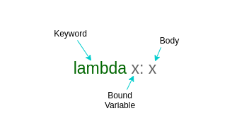

# IIFEs using lambda functions

IIFEs are *Immediately Invoked Function Expressions*. These are functions that are executed as soon as they are created. IIFEs require no explicit call to invoke the function. In Python, IIFEs can be created using the lambda function.

Here, created an IIFE that returns the cube of a number:

```python
(lambda x: x*x*x)(10)
```

```
1000
```

```python
# awesome
```

# Application of Lambda Functions with Different Functions

created a random dataset that contains information about a family of 5 people with their id, names, ages, and income per month. I will be using this dataframe to show you how to apply lambda functions using different functions on a dataframe in Python.

```python
df=pd.DataFrame({
                'id':[1,2,3,4,5],
                'name':['Asad','Saad','Numi','Roman','Maria'],
                'age':[20,25,15,10,30],
                'income':[4000,7000,200,0,10000]})
df
```

|  | id | name | age | income |
| --- | --- | --- | --- | --- |
| 0 | 1 | Asad | 20 | 4000 |
| 1 | 2 | Saad | 25 | 7000 |
| 2 | 3 | Numi | 15 | 200 |
| 3 | 4 | Roman | 10 | 0 |
| 4 | 5 | Maria | 30 | 10000 |

```python
# Without lambda we can do this by either of this approach:

# df['age'] = df['age'] + 3   # it will also work
df['age'] = [ age + 3 for age in df['age'] ]
df
```

|  | id | name | age | income |
| --- | --- | --- | --- | --- |
| 0 | 1 | Asad | 23 | 4000 |
| 1 | 2 | Saad | 28 | 7000 |
| 2 | 3 | Numi | 18 | 200 |
| 3 | 4 | Roman | 13 | 0 |
| 4 | 5 | Maria | 33 | 10000 |

# Application of Lambda with Apply

Let’s say we have got an error in the age variable. We recorded ages with a difference of 3 years. So, to remove this error from the Pandas dataframe, we have to add three years to every person’s age. We can do this with the **apply() function** in Pandas.

**apply() function** in Pandas calls the lambda function and applies it to every row or column of the dataframe and returns a modified copy of the dataframe:

```python
df['age']=df.apply(lambda x: x['age']+3,axis='columns')  # on frame
```

```python
df
```

|  | id | name | age | income |
| --- | --- | --- | --- | --- |
| 0 | 1 | Asad | 26 | 4000 |
| 1 | 2 | Saad | 31 | 7000 |
| 2 | 3 | Numi | 21 | 200 |
| 3 | 4 | Roman | 16 | 0 |
| 4 | 5 | Maria | 36 | 10000 |

```python
df['age']=df['age'].apply(lambda x: x+3) #on particular series
```

```python
df
```

|  | id | name | age | income |
| --- | --- | --- | --- | --- |
| 0 | 1 | Asad | 29 | 4000 |
| 1 | 2 | Saad | 34 | 7000 |
| 2 | 3 | Numi | 24 | 200 |
| 3 | 4 | Roman | 19 | 0 |
| 4 | 5 | Maria | 39 | 10000 |

# Application of Lambda with Filter

Now, let’s see how many of these people are above the age of 18.

We can do this using the **filter() function**.

The **filter() function** takes a lambda function and a Pandas series and applies the lambda function on the series and filters the data.

```python
list(filter(lambda x: x>18, df['age']))
```

```
[29, 34, 24, 19, 39]
```

# Application of Lambda with Map

You’ll be able to relate to the next statement. 🙂 It’s performance appraisal time and the income of all the employees gets increased by 20%. This means we have to increase the salary of each person by 20% in our Pandas dataframe.

We can do this using the map() function. This map() function maps the series according to input correspondence. It is very helpful when we have to substitute a series with other values.

```python
df['income']=list(map(lambda x: int(x+x*0.2),df['income']))

df
```

|  | id | name | age | income |
| --- | --- | --- | --- | --- |
| 0 | 1 | Asad | 29 | 4800 |
| 1 | 2 | Saad | 34 | 8400 |
| 2 | 3 | Numi | 24 | 240 |
| 3 | 4 | Roman | 19 | 0 |
| 4 | 5 | Maria | 39 | 12000 |

# Conditional Statements using Lambda Functions

Lambda functions also support conditional statements, such as if..else. This makes lambda functions very powerful.

Let’s say in the family dataframe we have to categorize people into ‘Adult’ or ‘Child’. For this, we can simply apply the lambda function to our dataframe:

```python
df['category']=df['age'].apply(lambda x: 'Adult' if x>=18 else 'Child')

df
```

|  | id | name | age | income | category |
| --- | --- | --- | --- | --- | --- |
| 0 | 1 | Asad | 29 | 4800 | Adult |
| 1 | 2 | Saad | 34 | 8400 | Adult |
| 2 | 3 | Numi | 24 | 240 | Adult |
| 3 | 4 | Roman | 19 | 0 | Adult |
| 4 | 5 | Maria | 39 | 12000 | Adult |

# Lambda with Reduce

Now, let’s see the total income of the family. To calculate this, we can use the reduce() function in Python. It is used to apply a particular function to the list of elements in the sequence. The reduce() function is defined in the ‘functools’ module.

For using the reduce() function, we have to import the functools module first:

```python
import functools

functools.reduce(lambda a,b: a+b, df['income'])
```

```
25440
```

# Summarizing and Computing Descriptive Statistics

```python
#do your self
```

# Correlation and Covariance

study link:https://machinelearningmastery.com/how-to-use-correlation-to-understand-the-relationship-between-variables/

#### Example:

```python
# In here we have installed pandas module datareader  by using !pip install pandas_datareader
```

```python
import pandas_datareader.data as web
```

```python
# dictionary comprehension

all_data = {ticker: web.get_data_yahoo(ticker) for ticker in ['AAPL', 'IBM', 'MSFT', 'GOOG']}
```

```python
all_data['AAPL']
```

| Date | High | Low | Open | Close | Volume | Adj Close |
| --- | --- | --- | --- | --- | --- | --- |
| 2016-01-28 | 23.629999 | 23.097500 | 23.447500 | 23.522499 | 222715200.0 | 21.792925 |
| 2016-01-29 | 24.334999 | 23.587500 | 23.697500 | 24.334999 | 257666000.0 | 22.545681 |
| 2016-02-01 | 24.177500 | 23.850000 | 24.117500 | 24.107500 | 163774000.0 | 22.334911 |
| 2016-02-02 | 24.010000 | 23.570000 | 23.855000 | 23.620001 | 149428800.0 | 21.883259 |
| 2016-02-03 | 24.209999 | 23.520000 | 23.750000 | 24.087500 | 183857200.0 | 22.316381 |
| ... | ... | ... | ... | ... | ... | ... |
| 2021-01-20 | 132.490005 | 128.550003 | 128.660004 | 132.029999 | 104319500.0 | 132.029999 |
| 2021-01-21 | 139.669998 | 133.589996 | 133.800003 | 136.869995 | 120529500.0 | 136.869995 |
| 2021-01-22 | 139.850006 | 135.020004 | 136.279999 | 139.070007 | 113907200.0 | 139.070007 |
| 2021-01-25 | 145.089996 | 136.539993 | 143.070007 | 142.919998 | 157611700.0 | 142.919998 |
| 2021-01-26 | 144.300003 | 141.369995 | 143.600006 | 142.989899 | 76091575.0 | 142.989899 |

1258 rows × 6 columns

```python
frame
```

|  | b | d | e |
| --- | --- | --- | --- |
| Utah | 0.727765 | 1.314090 | 0.130133 |
| Ohio | 0.078893 | 0.157854 | 0.437879 |
| Texas | 2.351619 | 0.956398 | 1.405248 |
| Oregon | 0.197710 | 0.006349 | 0.678122 |

```python
framing =frame.rename(columns={'b':"butterfly", 'd':"dog",'c':"Cat"},
                      index = {"Utah":22,"Ohio":33,"Texas":44,"Oregon":55})
framing
```

|  | butterfly | dog | e |
| --- | --- | --- | --- |
| 22 | 0.727765 | 1.314090 | 0.130133 |
| 33 | 0.078893 | 0.157854 | 0.437879 |
| 44 | 2.351619 | 0.956398 | 1.405248 |
| 55 | 0.197710 | 0.006349 | 0.678122 |

```python
framing.insert(1,'for', np.abs(framing["e"]))
```

```python
framing
```

|  | butterfly | for | dog | e |
| --- | --- | --- | --- | --- |
| 22 | 0.727765 | 0.130133 | 1.314090 | 0.130133 |
| 33 | 0.078893 | 0.437879 | 0.157854 | 0.437879 |
| 44 | 2.351619 | 1.405248 | 0.956398 | 1.405248 |
| 55 | 0.197710 | 0.678122 | 0.006349 | 0.678122 |